# Data Visualization: `ggplot` part 2

## Learning Goals

*At the end of this exercise, you will be able to:*  
1. Build stacked bar plots of categorical variables.  
2. Build side-by-side barplots using `position= "dodge"`.

## Resources

- [ggplot2 cheatsheet](https://www.rstudio.com/wp-content/uploads/2015/03/ggplot2-cheatsheet.pdf)

## Load the libraries

```r
library(tidyverse)
library(janitor)
library(palmerpenguins)
```

## Remove scientific notation

```r
options(scipen=999) #cancels the use of scientific notation for the session
```

## Data

**Database of vertebrate home range sizes.**  
Reference: Tamburello N, Cote IM, Dulvy NK (2015) Energy and the scaling of animal space use. The American Naturalist 186(2):196-211. http://dx.doi.org/10.1086/682070.  
Data: http://datadryad.org/resource/doi:10.5061/dryad.q5j65/1

```r
homerange <-
  read_csv("data/Tamburelloetal_HomeRangeDatabase.csv", na = c("", "NA", "\\"))
```

## A few more useful aesthetics

There are many options to create nice plots in ggplot. One useful trick is to store the plot as a new object and then experiment with geom’s and aesthetics. Let’s setup a plot that compares `log10.mass` and `log10.hra.` Notice that we are not specifying a geom.

```r
p <- homerange %>%
  ggplot(aes(x= log10.mass, y= log10.hra))
```

Here we are storing the base form of our plot as an object. This plot is not specific to any plot type, simpliest possible form.

Play with point size by adjusting the `size` argument.

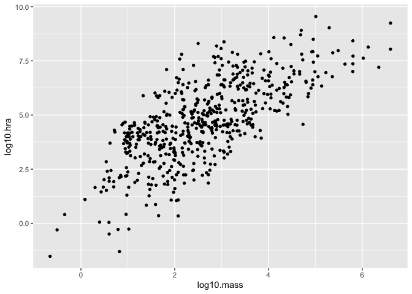

```r
p+geom_point(size=1.2) #adjusting the size of the dots on the scatter plot
```

Adjusting the size of the points with the size argument. Smaller points help with overplotting!

We can color the points by a categorical variable.

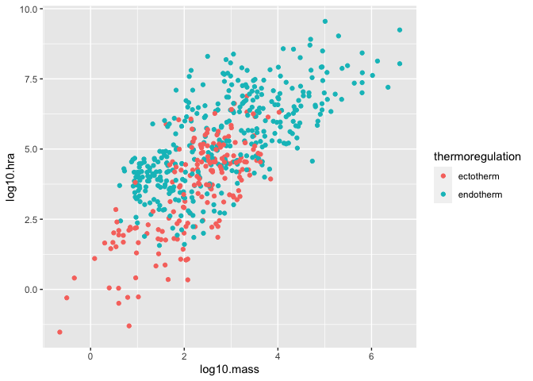

```r
p+geom_point(aes(color=thermoregulation),size=1.5)
```

picking p which is comparing 2 continuous variables and then color coding the types of continous variables we are looking at. For scatter plots, `color` is the same as `fill` function used in bar plots

We can also map shapes to another categorical variable.

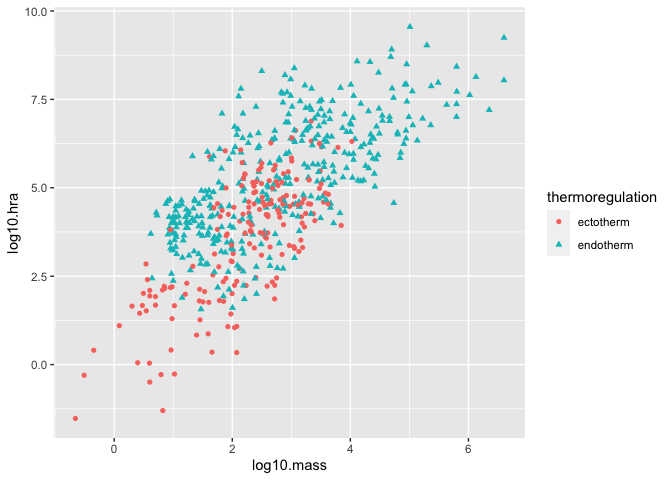

```r
p+geom_point(aes(color=thermoregulation, shape=thermoregulation),size=1.5)
```

## Barplots and multiple variables

At this point you should be comfortable building bar plots that show counts of observations using `geom_bar()`. Last time we explored the `fill` option as a way to bring color to the plot; i.e. we filled by the same variable that we were plotting. What happens when we fill by a different categorical variable?  
Let’s start by counting how many observations we have in each taxonomic group.

```r
homerange %>% count(taxon, sort=T)
```

```
## # A tibble: 9 × 2
##   taxon             n
##   <chr>         <int>
## 1 mammals         238
## 2 birds           140
## 3 marine fishes    90
## 4 snakes           41
## 5 river fishes     14
## 6 turtles          14
## 7 tortoises        12
## 8 lizards          11
## 9 lake fishes       9
```

Here we see 9 different taxa

Now let’s make a bar plot of these data.

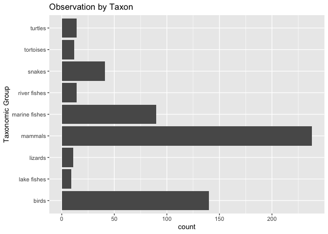

```r
homerange %>%
  ggplot(aes(x=taxon))+
  geom_bar()+
  coord_flip()+
  labs(title="Observation by Taxon",
       x= "Taxonomic Group")
```

Shape will change the shape of the shape used on the scatterplot based on the categorical variable that point is part of Labs is used to make lables

By specifying `fill=trophic.guild` we build a stacked bar plot that shows the proportion of a given taxonomic group that is an herbivore or carnivore.

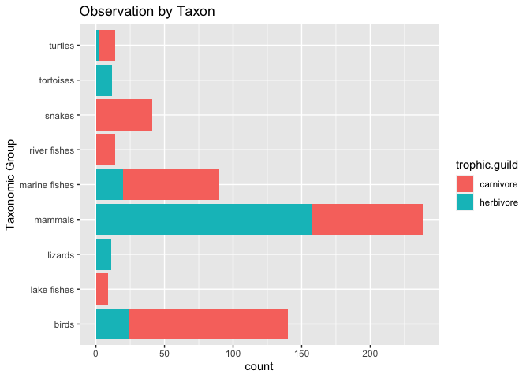

```r
homerange %>%
  ggplot(aes(x=taxon, fill=trophic.guild))+
  geom_bar()+
  coord_flip()+
  labs(title="Observation by Taxon",
       x= "Taxonomic Group")
```

We can use the `fill` function to enrich the information being shown in the plot. Filling by another categorical variable will fill each of the columns by the taxon (what is on the axis) and the specific trophic guilds that make up that taxon

Filling by the same thing you plot is not as informative

We can also have counts of each trophic guild within taxonomic group shown side-by-side by specifying `position="dodge"`.

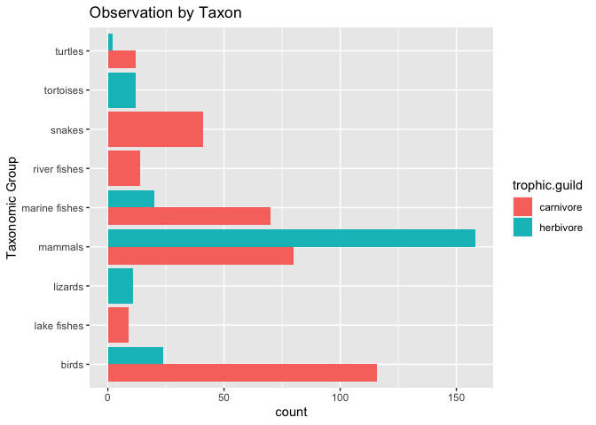

```r
homerange %>%
  ggplot(aes(x=taxon, fill=trophic.guild))+
  geom_bar(position="dodge")+
  coord_flip()+
  labs(title="Observation by Taxon",
       x= "Taxonomic Group")
```

Putting dodge splits the fill results

Here is the same plot oriented vertically.

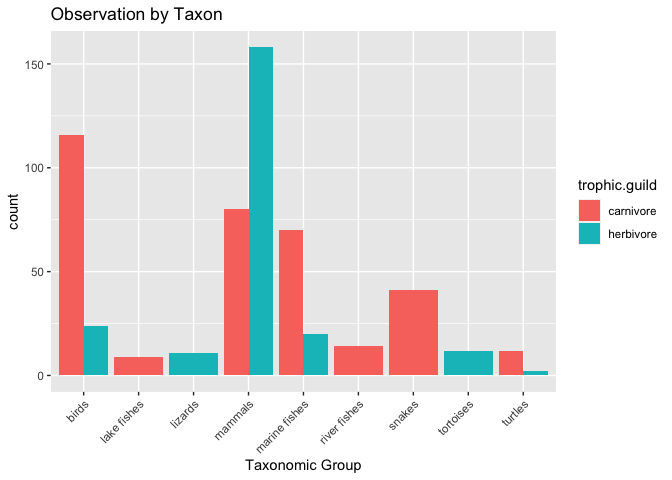

```r
homerange %>%
  ggplot(aes(x=taxon, fill=trophic.guild))+
  geom_bar(position="dodge")+
  theme(axis.text.x = element_text(angle=45, hjust=1))+ #adjustment of the x-axis elements
  labs(title="Observation by Taxon",
       x= "Taxonomic Group")
```

We can also scale all bars to a percentage.

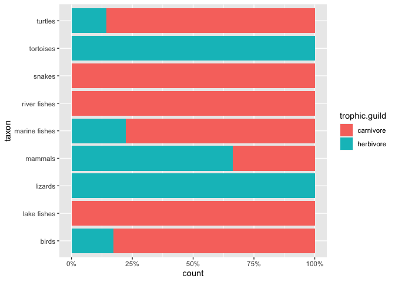

```r
homerange %>%
  ggplot(aes(x = taxon, fill = trophic.guild))+
  geom_bar(position = position_fill())+
  scale_y_continuous(labels = scales::percent)+
  coord_flip()
```

Scaling everything to a raw percentage to see values relative to each other. Done through adjustment to the geom_bar command

## Practice

For this practice, let’s use the [palmerpenguins](https://allisonhorst.github.io/palmerpenguins/articles/intro.html) data.

1. Make a bar plot that shows counts of individuals by island. Fill by species, and try both a stacked bar plot and `position="dodge"`.

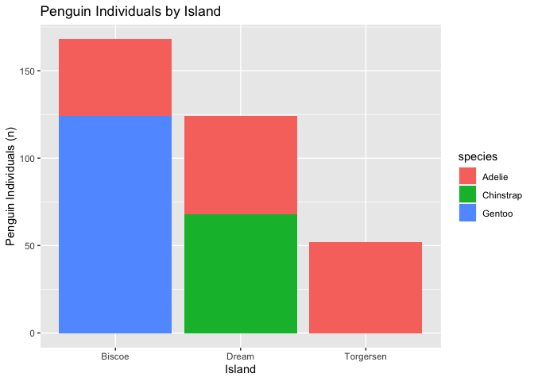

```r
penguins %>%
  ggplot(aes(x=island,fill=species))+
  geom_bar()+
  labs(title = "Penguin Individuals by Island",
       x="Island",
       y= "Penguin Individuals (n)")
```

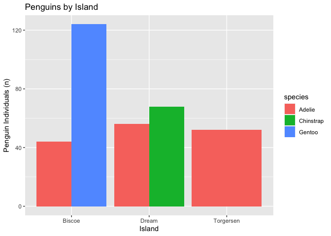

```r
penguins %>%
  ggplot(aes(x=island,fill=species))+
  geom_bar(position="dodge")+
  labs(title = "Penguins by Island",
       x="Island",
       y= "Penguin Individuals (n)")
```

2. Make another bar plot that shows the number of individuals by sex on each island?

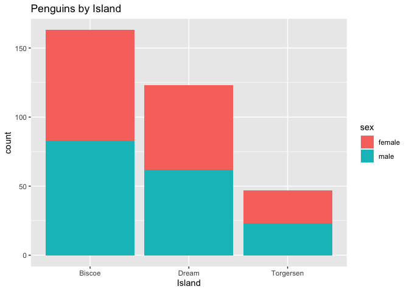

```r
penguins %>%
  filter(!sex=="NA") %>% #removes the NAs from the sex variable
  ggplot(aes(x=island,fill=sex))+
  geom_bar(na.rm = T)+
  labs(title = "Penguins by Island",
       x="Island")
```

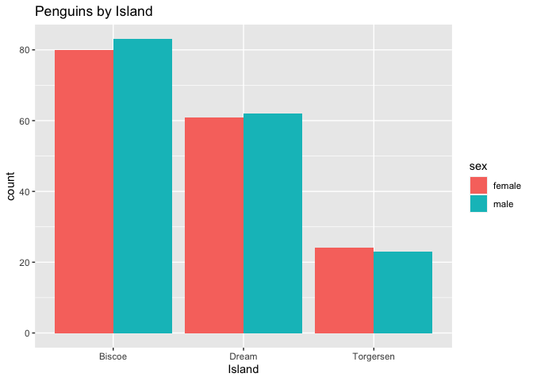

```r
penguins %>%
  filter(!sex=="NA") %>% #exclude sex from the data if it is equal to NA, only `!` works here
  ggplot(aes(x=island,fill=sex))+
  geom_bar(position="dodge",na.rm =T)+
  labs(title = "Penguins by Island",
       x="Island")
```

## Using `group`

In addition to `fill`, `group` is an aesthetic that accomplishes the same function but does not add color.

Here is a box plot that shows `log10.mass` by taxonomic `class.`

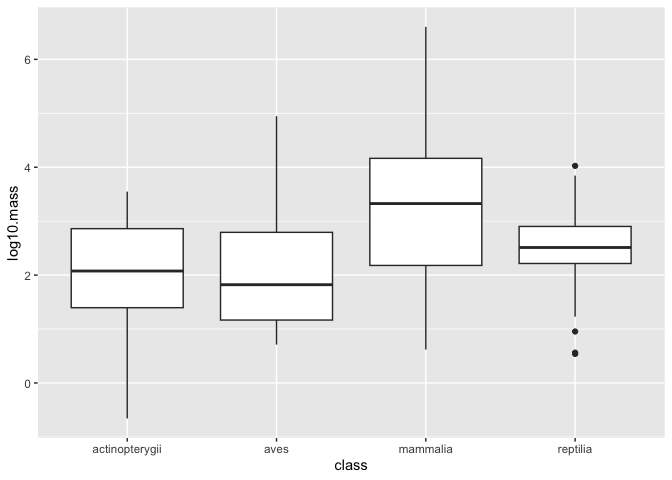

```r
homerange %>%
  ggplot(aes(x = class, y = log10.mass)) +
  geom_boxplot()
```

I use `group` to make individual box plots for each taxon within class. Pulls out all of the taxnomic classes so that each one ends up with its own little box plot.

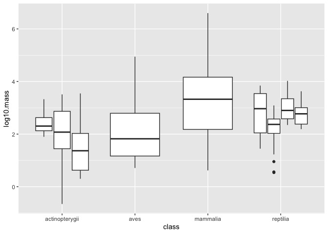

```r
homerange %>%
  ggplot(aes(x = class, y = log10.mass, group = taxon)) +
  geom_boxplot()
```

I can also use `fill` in addition to `group` to associate the different taxa with a color coded key.

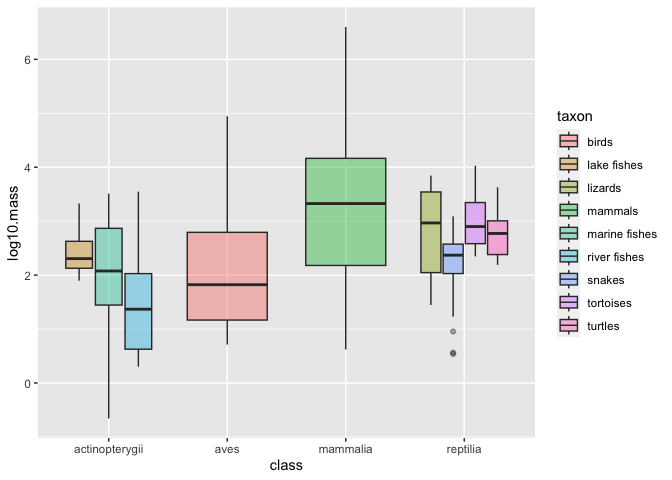

```r
homerange %>%
  ggplot(aes(x = class, y = log10.mass, group = taxon, fill=taxon)) +
  geom_boxplot(alpha=0.4)
```

If you only use `group` with taxon you get no color. If you `fill` with taxon you fill in each box plot with color. Alpha makes the coloring on the box plots transparent

## Wrap-up

Please review the learning goals and be sure to use the code here as a reference when completing the homework.  
–>[Home](https://jmledford3115.github.io/datascibiol/)